# **PCA and t-SNE Project: Auto MPG**

# **Marks: 30**

Welcome to the project on PCA and t-SNE. In this project, we will be using the **auto-mpg dataset**.

## **Context**

The shifting market conditions, globalization, cost pressure, and volatility are leading to a change in the automobile market landscape. The emergence of data, in conjunction with machine learning in automobile companies, has paved a way that is helping bring operational and business transformations.

The automobile market is vast and diverse, with numerous vehicle categories being manufactured and sold with varying configurations of attributes such as displacement, horsepower, and acceleration. We aim to find combinations of these features that can clearly distinguish certain groups of automobiles from others through this analysis, as this will inform other downstream processes for any organization aiming to sell each group of vehicles to a slightly different target audience.

You are a Data Scientist at SecondLife which is a leading used car dealership with numerous outlets across the US. Recently, they have started shifting their focus to vintage cars and have been diligently collecting data about all the vintage cars they have sold over the years. The Director of Operations at SecondLife wants to leverage the data to extract insights about the cars and find different groups of vintage cars to target the audience more efficiently.

## **Objective**

The objective of this problem is to **explore the data, reduce the number of features by using dimensionality reduction techniques like PCA and t-SNE, and extract meaningful insights**.

## **Dataset**

There are 8 variables in the data:

- mpg: miles per gallon
- cyl: number of cylinders
- disp: engine displacement (cu. inches) or engine size
- hp: horsepower
- wt: vehicle weight (lbs.)
- acc: time taken to accelerate from 0 to 60 mph (sec.)
- yr: model year
- car name: car model name

## **Importing the necessary libraries and overview of the dataset**

```python
import pandas as pd
import numpy as np
import matplotlib.pyplot as plt
import seaborn as sns

from sklearn.preprocessing import StandardScaler

from sklearn.decomposition import PCA
from sklearn.manifold import TSNE
```

### **Loading the data**

```python
data = pd.read_csv("auto-mpg.csv")
```

### **Data Overview**

- Observations
- Sanity checks

```python
data.info()
```

```
<class 'pandas.core.frame.DataFrame'>
RangeIndex: 398 entries, 0 to 397
Data columns (total 8 columns):
 #   Column        Non-Null Count  Dtype
---  ------        --------------  -----
 0   mpg           398 non-null    float64
 1   cylinders     398 non-null    int64
 2   displacement  398 non-null    float64
 3   horsepower    398 non-null    object
 4   weight        398 non-null    int64
 5   acceleration  398 non-null    float64
 6   model year    398 non-null    int64
 7   car name      398 non-null    object
dtypes: float64(3), int64(3), object(2)
memory usage: 25.0+ KB
```

**Observations:**

398 total lines in the dataset. No null entries, so there are no missing values. All columns are numerical except 'car name' and 'horsepower'. 'horsepower' is being treated as a character value which may need to be converted to integer later. We will need to investigate why horsepower column is treated as object, may be there are some non-integer or missing values in the column.

```python
data.head(25)
```

|  | mpg | cylinders | displacement | horsepower | weight | acceleration | model year | car name |
| --- | --- | --- | --- | --- | --- | --- | --- | --- |
| 0 | 18.0 | 8 | 307.0 | 130 | 3504 | 12.0 | 70 | chevrolet chevelle malibu |
| 1 | 15.0 | 8 | 350.0 | 165 | 3693 | 11.5 | 70 | buick skylark 320 |
| 2 | 18.0 | 8 | 318.0 | 150 | 3436 | 11.0 | 70 | plymouth satellite |
| 3 | 16.0 | 8 | 304.0 | 150 | 3433 | 12.0 | 70 | amc rebel sst |
| 4 | 17.0 | 8 | 302.0 | 140 | 3449 | 10.5 | 70 | ford torino |
| 5 | 15.0 | 8 | 429.0 | 198 | 4341 | 10.0 | 70 | ford galaxie 500 |
| 6 | 14.0 | 8 | 454.0 | 220 | 4354 | 9.0 | 70 | chevrolet impala |
| 7 | 14.0 | 8 | 440.0 | 215 | 4312 | 8.5 | 70 | plymouth fury iii |
| 8 | 14.0 | 8 | 455.0 | 225 | 4425 | 10.0 | 70 | pontiac catalina |
| 9 | 15.0 | 8 | 390.0 | 190 | 3850 | 8.5 | 70 | amc ambassador dpl |
| 10 | 15.0 | 8 | 383.0 | 170 | 3563 | 10.0 | 70 | dodge challenger se |
| 11 | 14.0 | 8 | 340.0 | 160 | 3609 | 8.0 | 70 | plymouth 'cuda 340 |
| 12 | 15.0 | 8 | 400.0 | 150 | 3761 | 9.5 | 70 | chevrolet monte carlo |
| 13 | 14.0 | 8 | 455.0 | 225 | 3086 | 10.0 | 70 | buick estate wagon (sw) |
| 14 | 24.0 | 4 | 113.0 | 95 | 2372 | 15.0 | 70 | toyota corona mark ii |
| 15 | 22.0 | 6 | 198.0 | 95 | 2833 | 15.5 | 70 | plymouth duster |
| 16 | 18.0 | 6 | 199.0 | 97 | 2774 | 15.5 | 70 | amc hornet |
| 17 | 21.0 | 6 | 200.0 | 85 | 2587 | 16.0 | 70 | ford maverick |
| 18 | 27.0 | 4 | 97.0 | 88 | 2130 | 14.5 | 70 | datsun pl510 |
| 19 | 26.0 | 4 | 97.0 | 46 | 1835 | 20.5 | 70 | volkswagen 1131 deluxe sedan |
| 20 | 25.0 | 4 | 110.0 | 87 | 2672 | 17.5 | 70 | peugeot 504 |
| 21 | 24.0 | 4 | 107.0 | 90 | 2430 | 14.5 | 70 | audi 100 ls |
| 22 | 25.0 | 4 | 104.0 | 95 | 2375 | 17.5 | 70 | saab 99e |
| 23 | 26.0 | 4 | 121.0 | 113 | 2234 | 12.5 | 70 | bmw 2002 |
| 24 | 21.0 | 6 | 199.0 | 90 | 2648 | 15.0 | 70 | amc gremlin |

```python
data.tail(25)
```

|  | mpg | cylinders | displacement | horsepower | weight | acceleration | model year | car name |
| --- | --- | --- | --- | --- | --- | --- | --- | --- |
| 373 | 24.0 | 4 | 140.0 | 92 | 2865 | 16.4 | 82 | ford fairmont futura |
| 374 | 23.0 | 4 | 151.0 | ? | 3035 | 20.5 | 82 | amc concord dl |
| 375 | 36.0 | 4 | 105.0 | 74 | 1980 | 15.3 | 82 | volkswagen rabbit l |
| 376 | 37.0 | 4 | 91.0 | 68 | 2025 | 18.2 | 82 | mazda glc custom l |
| 377 | 31.0 | 4 | 91.0 | 68 | 1970 | 17.6 | 82 | mazda glc custom |
| 378 | 38.0 | 4 | 105.0 | 63 | 2125 | 14.7 | 82 | plymouth horizon miser |
| 379 | 36.0 | 4 | 98.0 | 70 | 2125 | 17.3 | 82 | mercury lynx l |
| 380 | 36.0 | 4 | 120.0 | 88 | 2160 | 14.5 | 82 | nissan stanza xe |
| 381 | 36.0 | 4 | 107.0 | 75 | 2205 | 14.5 | 82 | honda accord |
| 382 | 34.0 | 4 | 108.0 | 70 | 2245 | 16.9 | 82 | toyota corolla |
| 383 | 38.0 | 4 | 91.0 | 67 | 1965 | 15.0 | 82 | honda civic |
| 384 | 32.0 | 4 | 91.0 | 67 | 1965 | 15.7 | 82 | honda civic (auto) |
| 385 | 38.0 | 4 | 91.0 | 67 | 1995 | 16.2 | 82 | datsun 310 gx |
| 386 | 25.0 | 6 | 181.0 | 110 | 2945 | 16.4 | 82 | buick century limited |
| 387 | 38.0 | 6 | 262.0 | 85 | 3015 | 17.0 | 82 | oldsmobile cutlass ciera (diesel) |
| 388 | 26.0 | 4 | 156.0 | 92 | 2585 | 14.5 | 82 | chrysler lebaron medallion |
| 389 | 22.0 | 6 | 232.0 | 112 | 2835 | 14.7 | 82 | ford granada l |
| 390 | 32.0 | 4 | 144.0 | 96 | 2665 | 13.9 | 82 | toyota celica gt |
| 391 | 36.0 | 4 | 135.0 | 84 | 2370 | 13.0 | 82 | dodge charger 2.2 |
| 392 | 27.0 | 4 | 151.0 | 90 | 2950 | 17.3 | 82 | chevrolet camaro |
| 393 | 27.0 | 4 | 140.0 | 86 | 2790 | 15.6 | 82 | ford mustang gl |
| 394 | 44.0 | 4 | 97.0 | 52 | 2130 | 24.6 | 82 | vw pickup |
| 395 | 32.0 | 4 | 135.0 | 84 | 2295 | 11.6 | 82 | dodge rampage |
| 396 | 28.0 | 4 | 120.0 | 79 | 2625 | 18.6 | 82 | ford ranger |
| 397 | 31.0 | 4 | 119.0 | 82 | 2720 | 19.4 | 82 | chevy s-10 |

**Interesting Observation: As I pointed out earlier, the reason why the'horsepower' column was being treated as an object was because there was a non-integer value in it. As shown in the data tail set, there is a '?' entry in this column. There might be more, so lets find out. But we will only need to do it for 'horsepower' as all other numerical columns were detected to be float or integer.**

```python
rows_with_quesmark = data[data['horsepower'] == '?']
print(rows_with_quesmark)
```

```
      mpg  cylinders  displacement horsepower  weight  acceleration  \
32   25.0          4          98.0          ?    2046          19.0
126  21.0          6         200.0          ?    2875          17.0
330  40.9          4          85.0          ?    1835          17.3
336  23.6          4         140.0          ?    2905          14.3
354  34.5          4         100.0          ?    2320          15.8
374  23.0          4         151.0          ?    3035          20.5

     model year              car name
32           71            ford pinto
126          74         ford maverick
330          80  renault lecar deluxe
336          80    ford mustang cobra
354          81           renault 18i
374          82        amc concord dl
```

## **Data Preprocessing and Exploratory Data Analysis**

- EDA is an important part of any project involving data.
- It is important to investigate and understand the data better before building a model with it.
- A few questions have been mentioned below which will help you approach the analysis in the right manner and generate insights from the data.
- Missing value treatment
- Feature engineering (if needed)
- Check the correlation among the variables
- Outlier detection and treatment (if needed)
- Preparing data for modeling
- Any other preprocessing steps (if needed)

**FEATURE ENGINEERING: Columns 'model year' and 'car name' have space in the header, which can cause problems in the dataset analysis so we are changing the name 'model year' to 'year' and 'car name' to 'brand'. Also we will change the column name 'horsepower' to 'hpwr', 'acceleration' to 'accl', and 'displacement' to 'disp' to save space.**

```python
data.rename(columns={'model year': 'year'}, inplace=True)
data.rename(columns={'car name': 'brand'}, inplace=True)
data.rename(columns={'horsepower': 'hpwr'}, inplace=True)
data.rename(columns={'displacement': 'disp'}, inplace=True)
data.rename(columns={'acceleration': 'accl'}, inplace=True)
```

```python
data.head()
```

|  | mpg | cylinders | disp | hpwr | weight | accl | year | brand |
| --- | --- | --- | --- | --- | --- | --- | --- | --- |
| 0 | 18.0 | 8 | 307.0 | 130 | 3504 | 12.0 | 70 | chevrolet chevelle malibu |
| 1 | 15.0 | 8 | 350.0 | 165 | 3693 | 11.5 | 70 | buick skylark 320 |
| 2 | 18.0 | 8 | 318.0 | 150 | 3436 | 11.0 | 70 | plymouth satellite |
| 3 | 16.0 | 8 | 304.0 | 150 | 3433 | 12.0 | 70 | amc rebel sst |
| 4 | 17.0 | 8 | 302.0 | 140 | 3449 | 10.5 | 70 | ford torino |

```python
data.nunique()
```

```
mpg          129
cylinders      5
disp          82
hpwr          94
weight       351
accl          95
year          13
brand        305
dtype: int64
```

**Observations: atlease some datapoints are repeated in all columns. So we should not drop any columns to avoid leaving out any valuable information.** **But we will replace the ? entries in the horsepower column with an assumed number that is realistic, lets say 100. we found the number of rows earlier in the notebook, so no need to complicate the code by reprinting them here.**

```python
data.loc[32, "hpwr"] = 100
data.loc[126, "hpwr"] = 100
data.loc[330, "hpwr"] = 100
data.loc[336, "hpwr"] = 100
data.loc[354, "hpwr"] = 100
data.loc[374, "hpwr"] = 100
```

```python
data.cylinders.value_counts()
```

```
4    204
8    103
6     84
3      4
5      3
Name: cylinders, dtype: int64
```

```python
data.hpwr.value_counts()
```

```
150    22
90     20
88     19
110    18
100    17
       ..
61      1
93      1
148     1
152     1
82      1
Name: hpwr, Length: 94, dtype: int64
```

```python
data.year.value_counts()
```

```
73    40
78    36
76    34
82    31
75    30
70    29
79    29
80    29
81    29
71    28
72    28
77    28
74    27
Name: year, dtype: int64
```

**FEATURE ENGINEERING: The column 'cylinders' has only five unique values namely 3,4,5,6,8. It would have made sense to convert this variable into a categorical variable or 'object'. However, car experts would disagree. They would explain that the number of cylinders is quantifiable and directly affects the performance of the car, for example displacement and consequently horsepower and acceleration. So we will not change the variable type of column 'cylinders'. But becuase year is a time instance and should not be analyzed as integer so we will convert column 'year' to an object. On the other hand, as discussed earlier, we should convert the 'hpwr' column to a numerical column so we can analyse it further by finding its mean, min and max values etc.**

```python
data['year'] = data['year'].astype(object)
data['hpwr'] = data['hpwr'].astype(int)
```

```python
data.info()
```

```
<class 'pandas.core.frame.DataFrame'>
RangeIndex: 398 entries, 0 to 397
Data columns (total 8 columns):
 #   Column     Non-Null Count  Dtype
---  ------     --------------  -----
 0   mpg        398 non-null    float64
 1   cylinders  398 non-null    int64
 2   disp       398 non-null    float64
 3   hpwr       398 non-null    int32
 4   weight     398 non-null    int64
 5   accl       398 non-null    float64
 6   year       398 non-null    object
 7   brand      398 non-null    object
dtypes: float64(3), int32(1), int64(2), object(2)
memory usage: 23.4+ KB
```

**OBSERVATION: Column Year has been converted to categorical object and horsepower has been converted to an integer.**

```python
data.describe().T
```

|  | count | mean | std | min | 25% | 50% | 75% | max |
| --- | --- | --- | --- | --- | --- | --- | --- | --- |
| mpg | 398.0 | 23.514573 | 7.815984 | 9.0 | 17.500 | 23.0 | 29.000 | 46.6 |
| cylinders | 398.0 | 5.454774 | 1.701004 | 3.0 | 4.000 | 4.0 | 8.000 | 8.0 |
| disp | 398.0 | 193.425879 | 104.269838 | 68.0 | 104.250 | 148.5 | 262.000 | 455.0 |
| hpwr | 398.0 | 104.402010 | 38.203079 | 46.0 | 76.000 | 95.0 | 125.000 | 230.0 |
| weight | 398.0 | 2970.424623 | 846.841774 | 1613.0 | 2223.750 | 2803.5 | 3608.000 | 5140.0 |
| accl | 398.0 | 15.568090 | 2.757689 | 8.0 | 13.825 | 15.5 | 17.175 | 24.8 |

```
mpg
Skew : 0.46
```

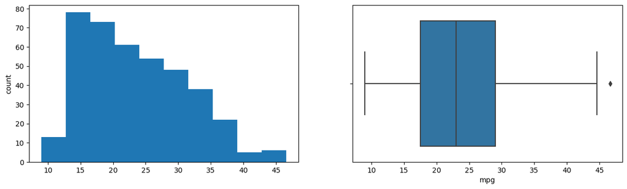

```
cylinders
Skew : 0.53
```

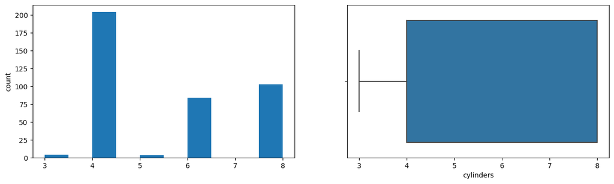

```
disp
Skew : 0.72
```

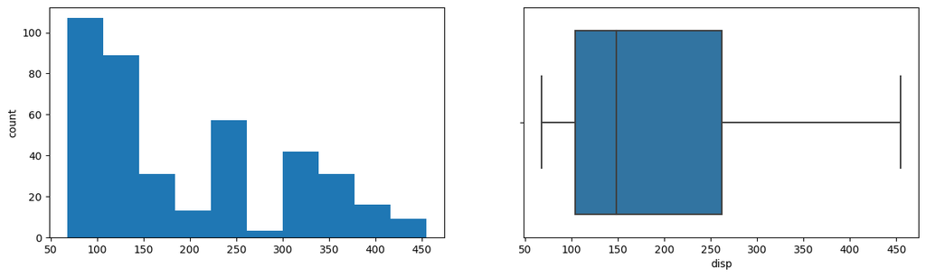

```
hpwr
Skew : 1.1
```

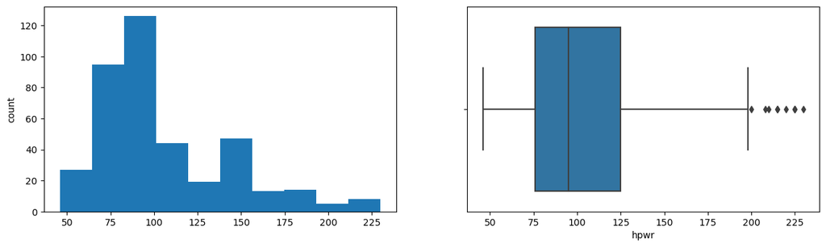

```
weight
Skew : 0.53
```

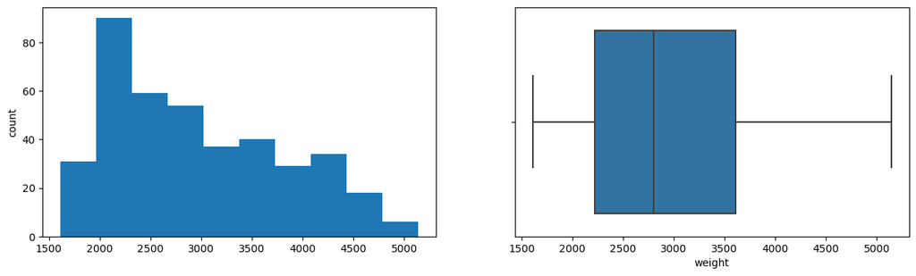

```
accl
Skew : 0.28
```

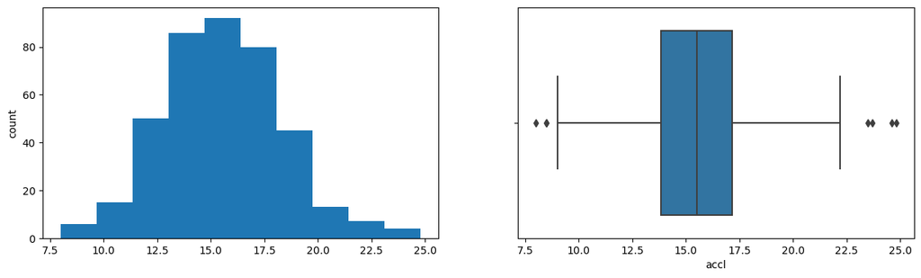

```
year
Skew : 0.01
```

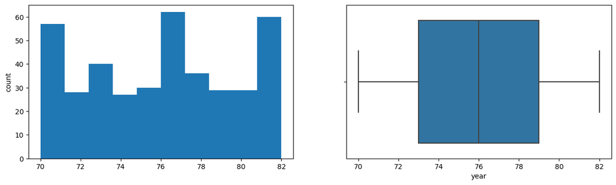

```
brand
```

[output not shown]

[output cut: 29 more lines]

[output not shown]

```python
cont_cols = list(data.columns)

for col in cont_cols:

    print(col)

    print('Skew :',round(data[col].skew(),2))

    plt.figure(figsize = (15, 4))

    plt.subplot(1, 2, 1)

    data[col].hist(bins = 10, grid = False)

    plt.ylabel('count')

    plt.subplot(1, 2, 2)

    sns.boxplot(x = data[col])

    plt.show()
```

**The boxplots are very informative. We can tell that there are no outliers in cylinders, displacement, weight, and year. Acceleration has a few outliers on either side. Horsepower has a significant number of outliers on the high end. Data for acceleration seems to be normally distributed. almost every other column is slightly skewed to the right. Please note that the error above is for the plot for 'brand', we can ignore this since we do not need a plot for brand.**

**Now lets look at heat map data to see correlation between different variables.**

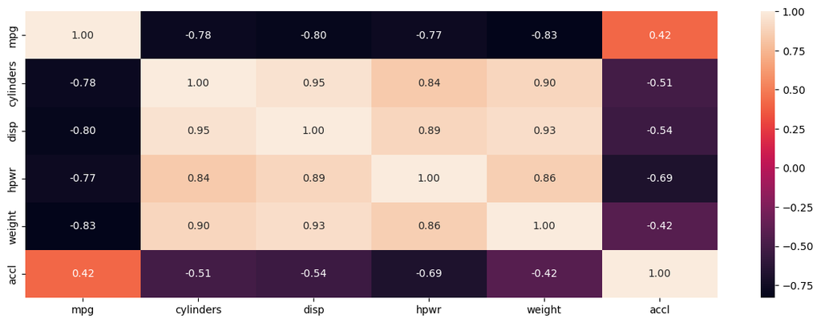

```python
plt.figure(figsize = (15, 5))

sns.heatmap(data.corr(numeric_only = True), annot = True, fmt = '0.2f')

plt.show()
```

### **Summary Statistics**

```python
data.describe().T
```

|  | count | mean | std | min | 25% | 50% | 75% | max |
| --- | --- | --- | --- | --- | --- | --- | --- | --- |
| mpg | 398.0 | 23.514573 | 7.815984 | 9.0 | 17.500 | 23.0 | 29.000 | 46.6 |
| cylinders | 398.0 | 5.454774 | 1.701004 | 3.0 | 4.000 | 4.0 | 8.000 | 8.0 |
| disp | 398.0 | 193.425879 | 104.269838 | 68.0 | 104.250 | 148.5 | 262.000 | 455.0 |
| hpwr | 398.0 | 104.402010 | 38.203079 | 46.0 | 76.000 | 95.0 | 125.000 | 230.0 |
| weight | 398.0 | 2970.424623 | 846.841774 | 1613.0 | 2223.750 | 2803.5 | 3608.000 | 5140.0 |
| accl | 398.0 | 15.568090 | 2.757689 | 8.0 | 13.825 | 15.5 | 17.175 | 24.8 |

**Observations: All columns have 398 values. The data values vary significantly from column to column for example the max values for weight is very high - 5140 as compared to most other variables. Similarly, the data has very high standard deviation for most columns. Acceleration seems to be an anomaly which seems to be the only column that is normally distributed. Scaling the data will benefit greatly, by making values of all columns comparable to each other.**

### **Scaling the data**

```python
#using 'StandardScaler' technique to scale the data
scaler = StandardScaler()
data_scaled = pd.DataFrame(scaler.fit_transform(data), columns = data.columns)
```

```python
data_scaled.head()
```

[output not shown]

```python
data_scaled.describe().T
```

|  | count | mean | std | min | 25% | 50% | 75% | max |
| --- | --- | --- | --- | --- | --- | --- | --- | --- |
| mpg | 398.0 | 7.141133e-17 | 1.001259 | -1.859374 | -0.770491 | -0.065919 | 0.702705 | 2.957335 |
| cylinders | 398.0 | -3.570567e-17 | 1.001259 | -1.444949 | -0.856321 | -0.856321 | 1.498191 | 1.498191 |
| disp | 398.0 | -1.785283e-17 | 1.001259 | -1.204411 | -0.856318 | -0.431404 | 0.658488 | 2.511784 |
| hpwr | 398.0 | -1.785283e-16 | 1.001259 | -1.530649 | -0.744384 | -0.246416 | 0.539850 | 3.291778 |
| weight | 398.0 | -1.606755e-16 | 1.001259 | -1.604943 | -0.882827 | -0.197362 | 0.753834 | 2.565185 |
| accl | 398.0 | -2.677925e-16 | 1.001259 | -2.747814 | -0.632879 | -0.024722 | 0.583435 | 3.351912 |
| year | 398.0 | -1.642461e-15 | 1.001259 | -1.627426 | -0.815074 | -0.002721 | 0.809631 | 1.621983 |

## **Principal Component Analysis**

```python
n = data_scaled.shape[1]

pca = PCA(n_components = 7, random_state = 1)

data_pca = pd.DataFrame(pca.fit_transform(data_scaled))

exp_var = pca.explained_variance_ratio_
```

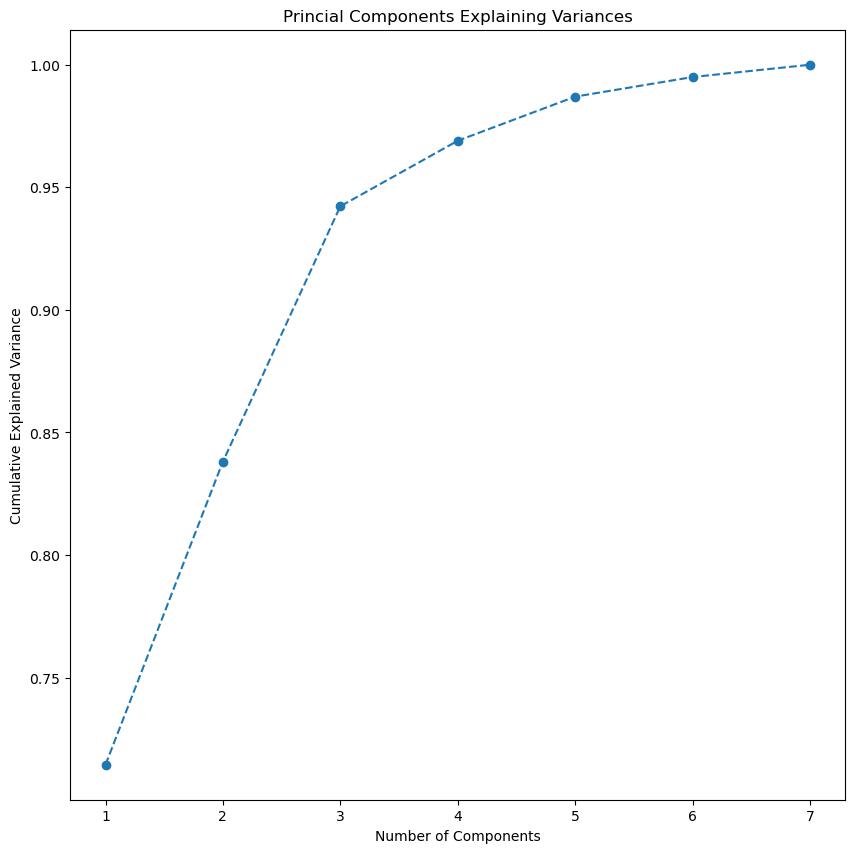

```python
# Principal component plotting
plt.figure(figsize = (10, 10))
#plotting for 1 through 7 principal components
plt.plot(range(1, 8), pca.explained_variance_ratio_.cumsum(), marker = 'o', linestyle = '--')

plt.title("Princial Components Explaining Variances")

plt.xlabel("Number of Components")

plt.ylabel("Cumulative Explained Variance")

plt.show()
```

**Observations:** Visually we can see that only 2 principal components can explain more than 80% of the variance. We can verify that by using the following code.

```python
sum = 0

for ix, i in enumerate(exp_var):

    sum = sum + i

    if(sum>0.80):
        print('Min # of Principal Components to explain atleast 80% variance=',ix + 1,)
        break
```

```
Min # of Principal Components to explain atleast 80% variance= 2
```

*And 3 principal components can take it upto 85% as we will see below*

```python
sum = 0

for ix, i in enumerate(exp_var):

    sum = sum + i

    if(sum>0.85):
        print('Min # of Principal Components to explain atleast 85% variance=',ix + 1,)
        break
```

```
Min # of Principal Components to explain atleast 85% variance= 3
```

#### **Interpret the coefficients of the first three principal components from the below DataFrame**

```python
cols = ['PC1', 'PC2', 'PC3']

pc1 = pd.DataFrame(np.round(pca.components_.T[:, 0:3], 2), index = data_scaled.columns, columns = cols)
pc1
```

|  | PC1 | PC2 | PC3 |
| --- | --- | --- | --- |
| mpg | -0.40 | -0.21 | -0.26 |
| cylinders | 0.42 | -0.19 | 0.14 |
| disp | 0.43 | -0.18 | 0.10 |
| hpwr | 0.42 | -0.09 | -0.17 |
| weight | 0.41 | -0.22 | 0.28 |
| accl | -0.28 | 0.02 | 0.89 |
| year | -0.23 | -0.91 | -0.02 |

**Observations:**

1st Principal component is related to vehicle performance features such as cylinders, displacement and horsepower. Consequently its also related to the mpg which is inversely proportional to the above mentioned features.

2nd PC seems to be related to the manufacture year of the vehicle.

3rd PC looks related to the acceleration of the vehicle.

#### **Visualize the data in 2 dimensions using the first two principal components**

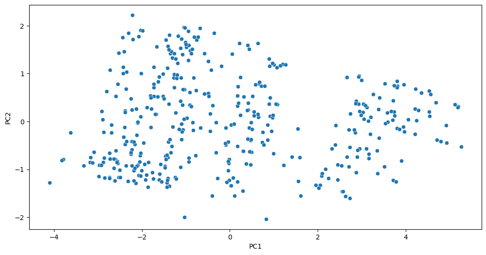

```python
plt.figure(figsize =(12,6))
sns.scatterplot (x=data_pca[0], y=data_pca[1])
plt.xlabel('PC1')
plt.ylabel('PC2')
plt.show()
```

**Observations:**

We can see that there a few outliers along the x-axis and the y-axis. For the two points on the bottom along the PC1 line, they may have a very unique manufacturing year or years since they are significantly different from the rest of the data set along PC2 axis. But its hard to interpret this plot any further than that.

We can also see some sort of clusters forming as we go from left to right. Hopefully, we will get more clarity with the t-SNE analyis.

## **t-SNE**

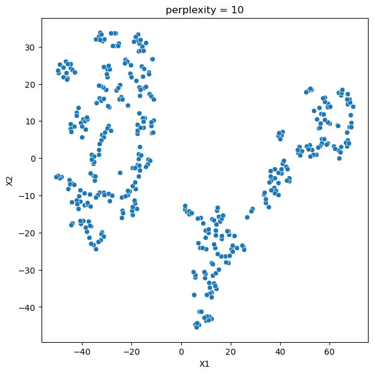

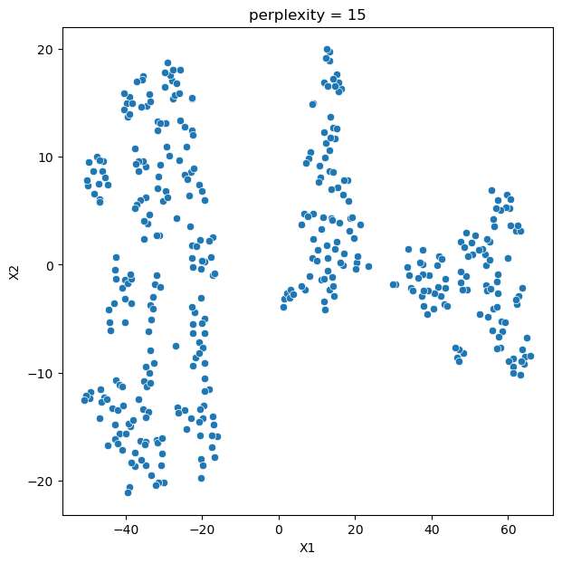

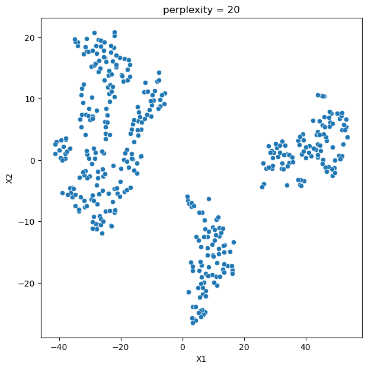

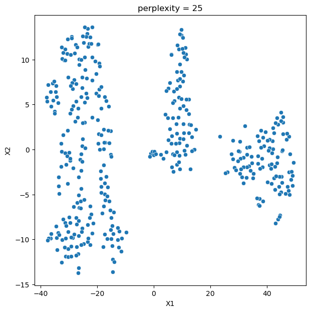

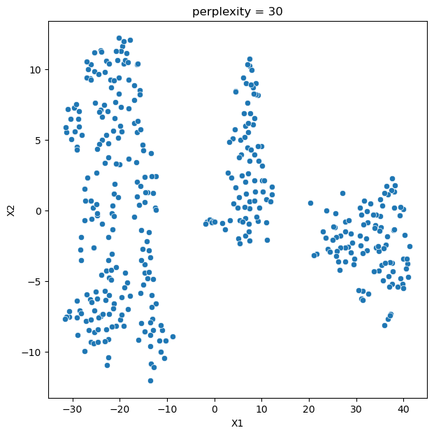

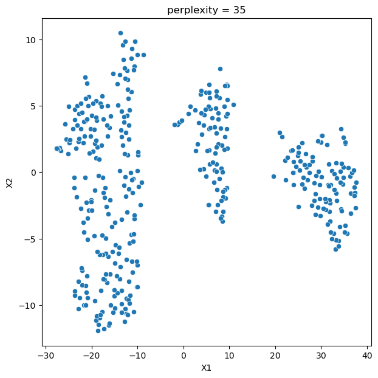

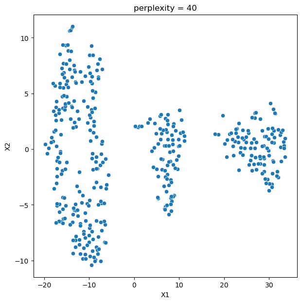

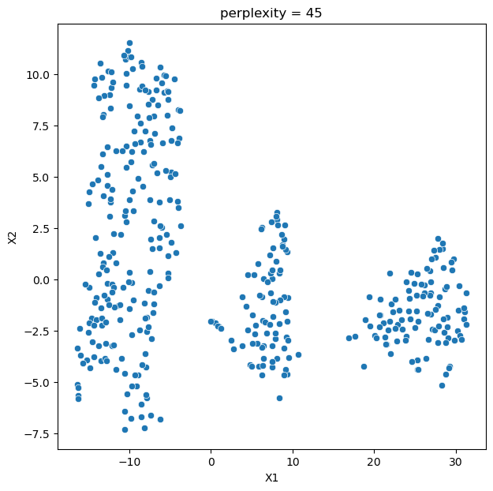

```python
for i in range(10, 50, 5):
    tsne = TSNE(n_components = 2, random_state = 1, perplexity = i)

    data_scaled_tsne = tsne.fit_transform(data_scaled)

    data_scaled_tsne = pd.DataFrame(data_scaled_tsne)

    data_scaled_tsne.columns = ['X1', 'X2']

    plt.figure(figsize = (7,7))

    sns.scatterplot(x = 'X1', y = 'X2', data = data_scaled_tsne)

    plt.title("perplexity = {}".format(i))
```

**Observations: Data is clearly grouped into atleast 3 separate groups. Graphs above with perplexity 20 and higher are good at distinguishing between different groups. I am picking the perplexity value of 35 which can offer the best analysis of the dataset. You can see that this has visually the least scattering within the first group on the left side. I will run it again separately to ease with further processing. Making the plot size larger to distinguish from the many plots above.**

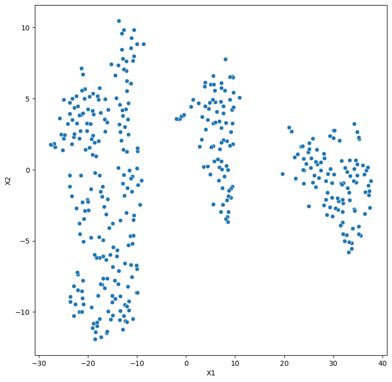

```python
tsne = TSNE(n_components = 2, random_state = 1, perplexity = 35)

data_scaled_tsne = tsne.fit_transform(data_scaled)


data_scaled_tsne = pd.DataFrame(data_scaled_tsne, columns = ["X1", "X2"])

plt.figure(figsize = (9, 9))

sns.scatterplot(x = 'X1', y = 'X2', data = data_scaled_tsne)

plt.show()
```

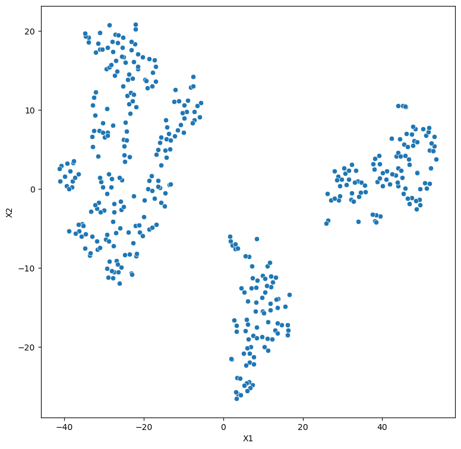

```python
tsne = TSNE(n_components = 2, random_state = 1, perplexity = 20)

data_scaled_tsne = tsne.fit_transform(data_scaled)


data_scaled_tsne = pd.DataFrame(data_scaled_tsne, columns = ["X1", "X2"])


plt.figure(figsize = (9, 9))

sns.scatterplot(x = 'X1', y = 'X2', data = data_scaled_tsne)

plt.show()
```

**IMPORTANT! I ran with perplexity 35 but the box plots and scatter plots did not make sense. So I changed the perplexity value to 20. as can be seen in the plot above. I overwrote the box plots so they are not available for perplexity 35 anymore. This saves some space in the code.**

**Observations: Now lets split up the data points into these 3 groups:**

```python
def grouping(x):
    first_component = x['X1']

    second_component = x['X2']

    if first_component < -2:
        return 'Group1'

    elif (first_component > -2) and (first_component < 18):
        return 'Group2'

    else:
        return 'Group3'

data_scaled_tsne['Groups'] = data_scaled_tsne.apply(grouping, axis = 1)
```

**OK, group assignment is complete. Lets visualize it now. Since the data is spread more along the X2 component (vertical), I have stretched the plot in the horizontal direction.**

[figure not shown]

```python
plt.figure(figsize = (7, 6))

sns.scatterplot(x = 'X1', y = 'X2', data = data_scaled_tsne, hue = 'Groups')
```

#### **Visualize the clusters w.r.t different variables using scatter plot and box plot**

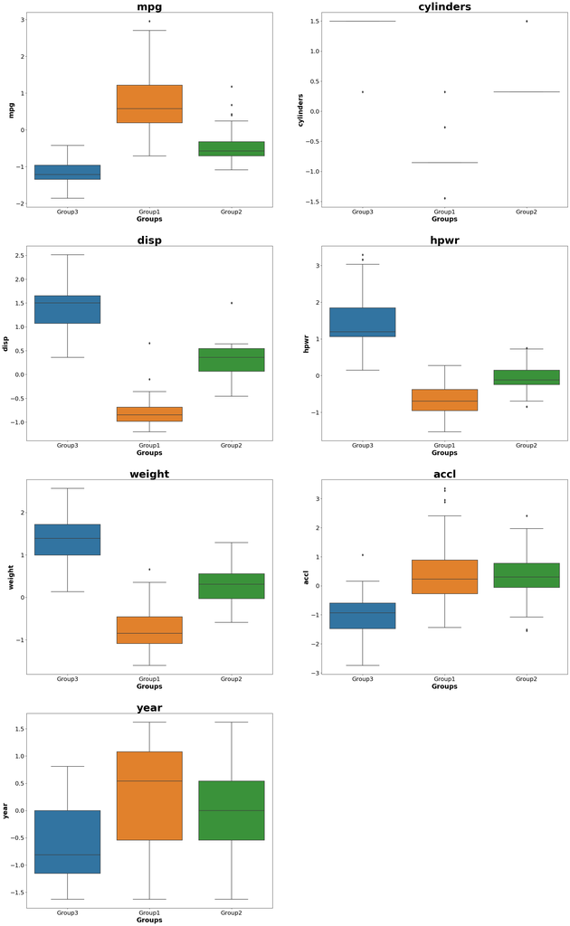

```python
allcolumns = data_scaled.columns.tolist()

plt.figure(figsize = (30, 50))

for i, variable in enumerate(allcolumns):
    plt.subplot(4, 2, i + 1)

    sns.boxplot(y=data_scaled[variable], x=data_scaled_tsne['Groups'])
    plt.xticks(fontsize=18)
    plt.yticks(fontsize=18)
    plt.xlabel('Groups', fontsize=20,fontweight='bold')
    plt.ylabel(variable, fontsize=20,fontweight='bold')
    plt.title(variable, fontsize=32, fontweight='bold')

plt.show()
```

**Observations:** *There are 3 groups in the data set. Group1 represents most fuel efficient vehicles. They have the lowest specs such as weight, displacement, which results in higher values of mpg(miles per gallon of fuel).*

*Group3 is the opposite with least values of mpg because they are most performance oriented cars.*

*Group2 however is somewhere in between.*

## **Actionable Insights and Recommendations**

**write your insights and recommendations here:**

One thing to observe from the last plot is that the vehicle's efficiency seems to be improving as the model year goes from older to newer.

Typical vintage vehicles that the dealership has sold can be grouped into three groups which can be understood to be performance based classes.

If we were to assign selling prices to the cars, we should keep in mind that group2 and group3 will not give us much flexibility in price range. We can experiment with a wide pricing range only for group1. For the same reason, group1 cars can offer promotional pricing from time to time to incentivize increased sales.